# diabetic

## Diabetes patient record: time series analysis and forecasting.

Data import and preprocessing  
Insulin  
Forecastiing with gradient boosted trees  
Facebook's prophet

In this notebook I analyze a time series of blood glucose measurements for a diabetes patient. The details of the records can be found in the [data source](https://archive.ics.uci.edu/ml/datasets/diabetes) made publicly available by Michael Kahn, MD, PhD, Washington University, St. Louis, MO.

The dataset consists of paper or electronic records for 70 patients. Here we focus on patient 1 (electronic records) in order to have a consistent and accurate record of time measurements.

```python
# usual imports
import pandas as pd
import numpy as np
import scipy.stats as sts

# ml libs
from fbprophet import Prophet
import xgboost as xgb

# metrics
from sklearn.metrics import mean_absolute_error, mean_squared_error

# plotting libs
import matplotlib.pyplot as plt
import seaborn as sns

from fbprophet.plot import plot_plotly
```

## Data import and preprocessing

The data have no header and the separator was set to tab. Let's import them and assign meaningful column names.

```python
data1 = pd.read_csv('data-01', sep='\t', header = None)
data1.columns = ['date', 'time', 'code', 'value']
```

```python
data1.head()
```

|  | date | time | code | value |
| --- | --- | --- | --- | --- |
| 0 | 04-21-1991 | 9:09 | 58 | 100 |
| 1 | 04-21-1991 | 9:09 | 33 | 9 |
| 2 | 04-21-1991 | 9:09 | 34 | 13 |
| 3 | 04-21-1991 | 17:08 | 62 | 119 |
| 4 | 04-21-1991 | 17:08 | 33 | 7 |

```python
data1.code.unique()
```

```
array([58, 33, 34, 62, 48, 65, 60])
```

The code values determine what type of value has been recorded: e.g. blood glucose, insulin, activity etc.  
In the case of patient 1 the recorded codes are the following.

33 = Regular insulin dose  
34 = NPH insulin dose  
48 = Unspecified blood glucose measurement  
58 = Pre-breakfast blood glucose measurement  
62 = Pre-supper blood glucose measurement  
65 = Hypoglycemic symptoms  
60 = Pre-lunch blood glucose measurement

Let's filter the dataset keeping only desired codes related to blood glucose measurements.

```python
desired_codes = [48, 58, 60, 62]
```

```python
#create a df with desired_codes only
bg_df= data1[data1['code'].isin(desired_codes)].copy()
```

Side note: when slicing a dataframe to a copy it is always a good idea to enforce it with the `.copy()` method. This way we avoid the dreadful `SettingWithCopy` warning in pandas on one hand and possible mistakes (especially with large dataframes and lots of data) down the line after a few tens or worse hundreds of lines of code. More on this can be found in the [pandas manual](https://pandas.pydata.org/pandas-docs/stable/user_guide/indexing.html#returning-a-view-versus-a-copy) and in this excellent [dataquest blog post](https://www.dataquest.io/blog/settingwithcopywarning/).

```python
# examine the data types
bg_df.info(verbose = True)
```

```
<class 'pandas.core.frame.DataFrame'>
Int64Index: 369 entries, 0 to 940
Data columns (total 4 columns):
 #   Column  Non-Null Count  Dtype
---  ------  --------------  -----
 0   date    369 non-null    object
 1   time    369 non-null    object
 2   code    369 non-null    int64
 3   value   369 non-null    int64
dtypes: int64(2), object(2)
memory usage: 14.4+ KB
```

To be able to work with timeseries data we should create pandas a datetime object. Columns `date` and `time` are objects. Let's confirm that we are dealing with strings. Then we will use them to create a new datetime object, called `ds` (more on that later), and then just drop them.

```python
type(bg_df['date'].iloc[0]), type(bg_df['time'].iloc[0])
```

```
(str, str)
```

```python
bg_df.loc[:,'ds'] = bg_df.loc[:,('date')].str.cat(bg_df.loc[:,('time')], sep = ' ')
bg_df['ds'] = pd.to_datetime(bg_df['ds'])
bg_df.rename(columns = {'value':'y'}, inplace = True)
bg_df = bg_df.loc[:, ('ds', 'y')].copy()
bg_df = bg_df.set_index(keys = 'ds', drop = True).copy()
```

```python
bg_df.head()
```

| ds | y |
| --- | --- |
| 1991-04-21 09:09:00 | 100 |
| 1991-04-21 17:08:00 | 119 |
| 1991-04-21 22:51:00 | 123 |
| 1991-04-22 07:35:00 | 216 |
| 1991-04-22 16:56:00 | 211 |

```python
print(f"Data collection started on {bg_df.index.min().strftime('%A')}, {bg_df.index.min().date()} at {bg_df.index.min().time()}")
```

```
Data collection started on Sunday, 1991-04-21 at 09:09:00
```

```python
print(f"Data collection ended on {bg_df.index.max().strftime('%A')}, {bg_df.index.max().date()} at {bg_df.index.max().time()}")
```

```
Data collection ended on Tuesday, 1991-09-03 at 07:20:00
```

```python
ts = (bg_df.index.max() - bg_df.index.min()).total_seconds()
t_min = np.round(ts/60., 2)
t_hours = np.round(t_min/60., 2)
t_days = np.round(t_hours/24., 2)
print(f"Total collection time: {t_hours} hours or {t_days} days")
```

```
Total collection time: 3238.18 hours or 134.92 days
```

## Insulin

In this section I create two dataframes for the doses of insulin (regular and NPH) following the same steps as above. The goal is to plot their time marks on the same plot as the blood glucose measurements and observe if there are any correlations worth investigating or incorporating in the prediction.

```python
# NPH insulin
nph_df = data1[data1['code'].isin([34])].copy()
```

```python
nph_df.loc[:,'ds'] = nph_df.loc[:,'date'].str.cat(nph_df.loc[:,'time'], sep=' ')
```

```python
nph_df['ds'] = pd.to_datetime(nph_df['ds'])
```

```python
nph_df.drop(columns = ['date', 'time'], inplace=True)
```

```python
nph_df = nph_df.set_index(keys = 'ds', drop = True).copy()
nph_df.head()
```

| ds | code | value |
| --- | --- | --- |
| 1991-04-21 09:09:00 | 34 | 13 |
| 1991-04-22 07:35:00 | 34 | 13 |
| 1991-04-23 07:25:00 | 34 | 13 |
| 1991-04-24 07:52:00 | 34 | 14 |
| 1991-04-25 07:29:00 | 34 | 14 |

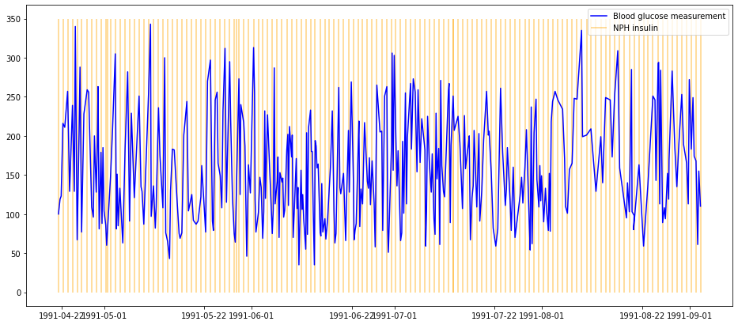

```python
plt.figure(figsize = (16, 7))
plt.plot(bg_df.index, bg_df['y'], c = 'b', label = 'Blood glucose measurement')
plt.vlines(nph_df.index, ymin = 0, ymax = 350, colors = 'orange',
           ls = '-', label = 'NPH insulin', alpha = 0.5)
plt.legend();
```

```python
# regular insulin dose
insulin_df = data1[data1['code'].isin([33])].copy()
insulin_df.loc[:,'ds'] = insulin_df.loc[:,'date'].str.cat(insulin_df.loc[:,'time'], sep=' ')
insulin_df['ds'] = pd.to_datetime(insulin_df['ds'])
insulin_df.drop(columns = ['date', 'time'], inplace=True)
insulin_df = insulin_df.set_index(keys = 'ds', drop = True).copy()
insulin_df.head()
```

| ds | code | value |
| --- | --- | --- |
| 1991-04-21 09:09:00 | 33 | 9 |
| 1991-04-21 17:08:00 | 33 | 7 |
| 1991-04-22 07:35:00 | 33 | 10 |
| 1991-04-22 13:40:00 | 33 | 2 |
| 1991-04-22 16:56:00 | 33 | 7 |

[figure not shown]

```python
plt.figure(figsize = (16, 7))
plt.plot(bg_df.index, bg_df['y'], c = 'b', label = 'Blood glucose measurement')
plt.vlines(insulin_df.index, ymin = 0, ymax = 350, colors = 'green',
           ls = '--', alpha = 0.4, label = 'Regular insulin')
plt.legend();
```

It looks like there is nothing that stands out to the eye. The task of correlating insulin dose to blood glucose measurement should be handled separately with numerical and statistical tools.

Next, I plot the values of blood glucose measurements along with their daily and weekly averages to see if trends are indicated. Finally I include the standard deviation of the daily average as a measure of spread of the blood glucose over the day.

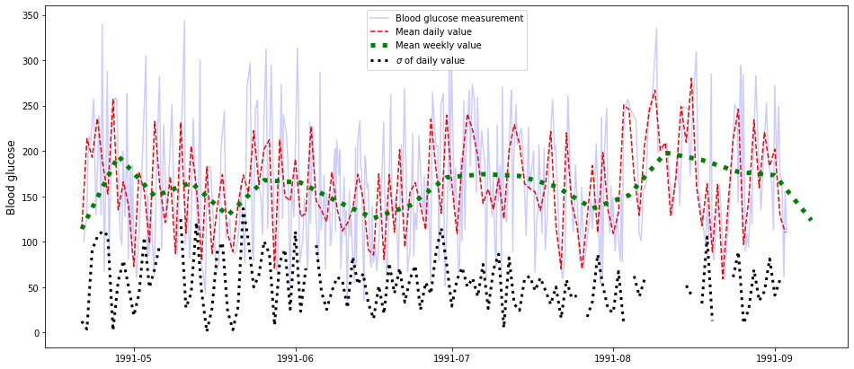

```python
plt.figure(figsize = (16, 7))
plt.plot(bg_df['y'], c = 'b', alpha = 0.2, label = 'Blood glucose measurement')
plt.plot(bg_df.resample('D').mean(), 'r--', label = 'Mean daily value')
plt.plot(bg_df.resample('W').mean(), 'g:', linewidth = 5, label = 'Mean weekly value')
plt.plot(bg_df.resample('D').std(), 'k:', linewidth = 3, label = '$\sigma$ of daily value')
plt.ylabel('Blood glucose', fontsize =12)
plt.legend();
```

## Forecasting with gradient boosted trees.

In order to predict univariate time series we first have to work with the data to bring it in a format that is useful for any ML algorithm. (The ideas behind multivariate forecasting, that is predicting multiple values in a sequence, are similar). Also, since the data is essentially a sequence of values, therefore, we will use a sliding window technique where all previous values are used to predict the next one. Long story short we have to bring the data from this format

```
time, value
1, 100
2, 119
3, 123
4, 216
5, 211
```

into this format:

```
X, y
NaN, 100
100, 119
119, 123
123, 216
216, ?
```

where the last value noted with "?" is to be predicted. In reality, algorithms learn much better if you feed them the past n, where n>1, values. If we are to add one more value the training has to be repeated on the entire sequence of previous values in order to achieve the best results.

Next I create a class to handle the above tasks.

```python
class UniForecast():
    """
    Class to use in time-series analysis of univariable forecasts.
    """

    def create_features(self, s, n = 3):
        """
        Creates n sliding window features of a univariate variable stored in s
        n: int
        s: pandas series holding the parameter

        Returns
        df: expanded df with n features
        """
        #make sure the user passed a pandas series object
        assert isinstance(s, pd.Series) == True, 'I need a series to work on...'
        assert s.isna().sum() == 0, 'Series contains nan values ...'
        #store the shifted series
        store_shifts = []
        #create the n shifted series
        for i in range(0, n+1):
            store_shifts.append(s.shift(i).copy())
        #reverse the stored series to reflect a supervised series
        store_shifts.reverse()
        df = pd.concat(store_shifts, ignore_index = True, axis =1)
        #create appropriate feature names
        feat_names = []
        for i in range(0, n):
            feat_names.append("x"+str(i))
        #add the target's name
        feat_names.append("y")
        df.columns = feat_names

        return df.iloc[n:, :].reset_index(drop=True).copy()

    def walk_fwd(self, df, model, test_samples = 20):
        """
        Performs a walk forward validation on the last test_samples number of data in df
        df: expanded dataframe from create_features
        test_samples: number of samples to test the algorithm on

        Returns
        -------
        preds, real: list
        Lists of predictions and reported values
        """
        #create the initial slice on which the algorithm will be trained on
        train_data = df.iloc[:-test_samples, :].copy()
        Xtrain = train_data.iloc[:-test_samples,:-1].copy()
        ytrain = train_data.iloc[:-test_samples,-1].copy()
        #fit the on the initial slice
        model.fit(Xtrain, ytrain)
        #create two lists to hold the recorded (real) and predicted values
        preds, real = [], []
        for i in range(0, test_samples):
            #append the real value to be predicted from the test set
            real.append(df.iloc[len(df)-test_samples + i, -1])
            #create a dataframe of the incoming vector that predicts the next value
            x = df.iloc[len(df) - test_samples + i, :-1].to_frame().T
            preds.append(model.predict(x))
            #update the training data by adding the first out the test_samples at the bottom
            update_train_data = df.iloc[: -test_samples + i, :].copy()
            update_Xtrain = df.iloc[:-test_samples+i, :-1].copy()
            update_ytrain = df.iloc[:-test_samples+i, -1].copy()
        #retrain model with the added point
            model.fit(update_Xtrain, update_ytrain)
        return real, preds
```

```python
#instantiate the class
uf = UniForecast()
```

```python
# use the create features method to create a df with 3 features i.e. the algorithm learns the next value by examining the previous 3
df1 = uf.create_features(bg_df.iloc[:, 0].reset_index(drop=True), n=3)
# make the predictions
real, preds = uf.walk_fwd(df = df1,
                      model = xgb.XGBRegressor(n_estimators = 500, max_depth = 2, objective = 'reg:squarederror'))
```

```python
# predictions of model are arrays - conver to list.
preds = [p[0] for p in preds]
```

Let's drill into the predictions a bit. We plot a histogram of the real values and the predictions (orange color).

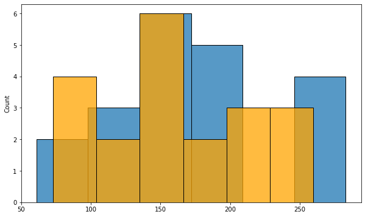

```python
fig = plt.figure(figsize = (10, 6))
ax = fig.add_subplot(1, 1, 1)
sns.histplot(real, ax = ax)
sns.histplot(preds, color = 'orange', ax = ax);
```

The histogram suggests that the distribution of predictions is very similar to that of the real values. To further probe in this I run a Mann-Whittney U test and extract the p-value. The null hypothesis is that the test draws from distributions with the same median.

```python
statistic, p_val = sts.mannwhitneyu(real, preds)
print(f"The p value of the test is {np.round(p_val, 3)}.")
if p_val < 0.05:
    print("Evidence suggest to reject Ho.")
else:
    print("Evidence suggest to accept Ho.")
```

```
The p value of the test is 0.357.
Evidence suggest to accept Ho.
```

Therefore, the test cannot differentiate between the distributions of values of `real` and `preds` lists. This is a good sign that the algorithm is on a good path.

It's worth noting that the class can handle multiple algorithms and is not specifically built for XGBoost regression. The obvious limitation is the use of sklearn notation for `fit` and `predict`.

Let's make more explicit plots of the results.

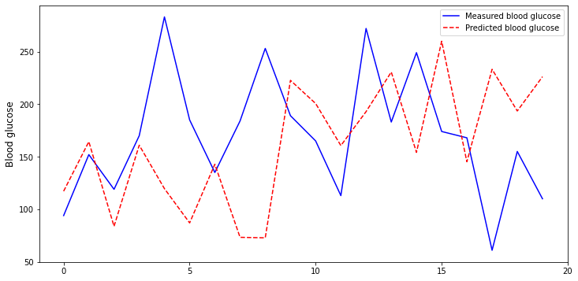

```python
plt.figure(figsize = (12, 6))
plt.plot(real, 'b-', label = 'Measured blood glucose')
plt.plot(preds, 'r--', label = 'Predicted blood glucose')
plt.ylabel("Blood glucose", fontsize = 12)
plt.xticks(ticks = range(0, len(preds)+1, 5))
plt.legend();
```

Not bad. There are some values that are very well predicted while others are off. Still, the algorithm doesn't go wild and remains with the range of the last 20 measured values. Now let's put things into persepective. We turn the `preds` list into a dataframe indexed with the last 20 indexes of the `bg_df` and plot together to see if the algorithm is able to catch trends.

```python
preds_df = pd.DataFrame(np.array(preds),columns = ['yhat'], index = range(len(bg_df)-len(preds), len(bg_df)))
```

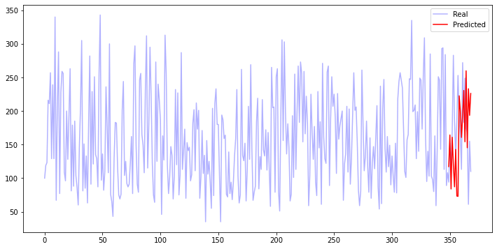

```python
plt.figure(figsize = (12, 6))
plt.plot(bg_df['y'].reset_index(drop=True), 'b-', alpha = 0.3, label = 'Real')
# plt.plot(real, 'b--', label = 'Real')
plt.plot(preds_df['yhat'], 'r-', label = 'Predicted')
plt.legend();
```

Looking at things from this perspective it looks like the algorithm is indeed trying to catch a jump in the values of blood glucose! Also, the predictions do not look that far off taking into account the standard deviation of the measured values in that time interval.

An extra step here would be to estimate confidence intervals (c.i.) for the predictions. This would require trying several models and form a distribution of responses from which c.i. is calculated. (Maybe in a future update of this notebook).

Final step: I calculate the mean absolute error of the prediction.

```python
mae = mean_absolute_error(real, preds)
np.round(mae, 3)
```

```
70.675
```

## Facebook's prophet

I now turn to examine the predictions that [facebook's prophet](http://facebook.github.io) (`fbprophet`) package gives on the series. Prophet will try to fit linear (default) or non-linear function on the series looking for a trend, seasonality, cyclic patterns, and irregularities. The predictions are made assuming a generalized additive model (GAM).

The advantage of `fbprophet` is that it has been built to be used without a deep knowledge of statistics around time-series analyis.

```python
# prophet requires a df with 2 cols with names: ds, y
# let's create it
bg_df = bg_df.reset_index().copy()
```

```python
bg_df.shape
```

```
(369, 2)
```

I define the first 300 observations as training data and will run a prediction on the full set after training.

```python
train_df = bg_df.iloc[:301, :].copy()
```

```python
#instantiate the Prophet class with yearly seasonality off
prophet = Prophet(growth = 'linear',
                  weekly_seasonality = True,
                 daily_seasonality = True,
                 yearly_seasonality = False)
```

```python
# run the fit method to train the model
prophet.fit(train_df)
```

```
<fbprophet.forecaster.Prophet at 0x7fe620d9c940>
```

Prophet will output a dataframe of the predictions with each timestamp (ds) analyzed in trend, additive terms, seasonal terms, and the final sum is the prediction (yhat). I create a `forecast` dataframe to store the results.

```python
forecast = prophet.predict(bg_df)
forecast.head()
```

|  | ds | trend | yhat_lower | yhat_upper | trend_lower | trend_upper | additive_terms | additive_terms_lower | additive_terms_upper | daily | daily_lower | daily_upper | weekly | weekly_lower | weekly_upper | multiplicative_terms | multiplicative_terms_lower | multiplicative_terms_upper | yhat |
| --- | --- | --- | --- | --- | --- | --- | --- | --- | --- | --- | --- | --- | --- | --- | --- | --- | --- | --- | --- |
| 0 | 1991-04-21 09:09:00 | 136.126888 | 82.488539 | 257.249492 | 136.126888 | 136.126888 | 31.165188 | 31.165188 | 31.165188 | 50.376030 | 50.376030 | 50.376030 | -19.210842 | -19.210842 | -19.210842 | 0.0 | 0.0 | 0.0 | 167.292076 |
| 1 | 1991-04-21 17:08:00 | 136.132570 | 66.902627 | 232.498700 | 136.132570 | 136.132570 | 15.799656 | 15.799656 | 15.799656 | 26.155872 | 26.155872 | 26.155872 | -10.356216 | -10.356216 | -10.356216 | 0.0 | 0.0 | 0.0 | 151.932225 |
| 2 | 1991-04-21 22:51:00 | 136.136639 | 66.884307 | 234.566205 | 136.136639 | 136.136639 | 11.235103 | 11.235103 | 11.235103 | 13.124258 | 13.124258 | 13.124258 | -1.889155 | -1.889155 | -1.889155 | 0.0 | 0.0 | 0.0 | 147.371741 |
| 3 | 1991-04-22 07:35:00 | 136.142854 | 80.809322 | 245.764480 | 136.142854 | 136.142854 | 29.673194 | 29.673194 | 29.673194 | 23.314128 | 23.314128 | 23.314128 | 6.359067 | 6.359067 | 6.359067 | 0.0 | 0.0 | 0.0 | 165.816048 |
| 4 | 1991-04-22 16:56:00 | 136.149509 | 80.263175 | 249.058773 | 136.149509 | 136.149509 | 30.590593 | 30.590593 | 30.590593 | 27.567815 | 27.567815 | 27.567815 | 3.022778 | 3.022778 | 3.022778 | 0.0 | 0.0 | 0.0 | 166.740102 |

Let's plot predictions and values on the same plot. Prophet (linear) seems to have a good grasp of the trend but struggles with spikes of activity.

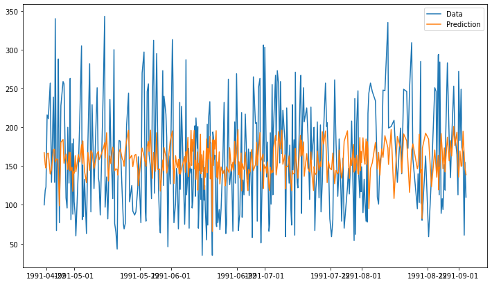

```python
plt.figure(figsize = (12, 7))
plt.plot(bg_df['ds'], bg_df['y'], label = 'Data')
plt.plot(forecast['ds'], forecast['yhat'], label = 'Prediction')
plt.legend();
```

Let's use Prophet's interface to plot confidence intervals and trends.

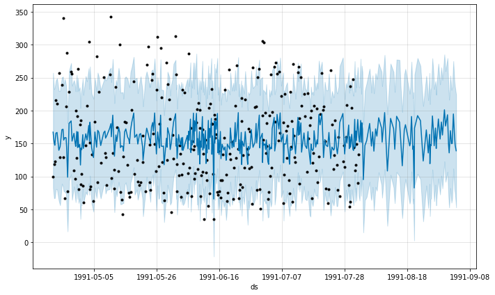

```python
fig1 = prophet.plot(forecast)
```

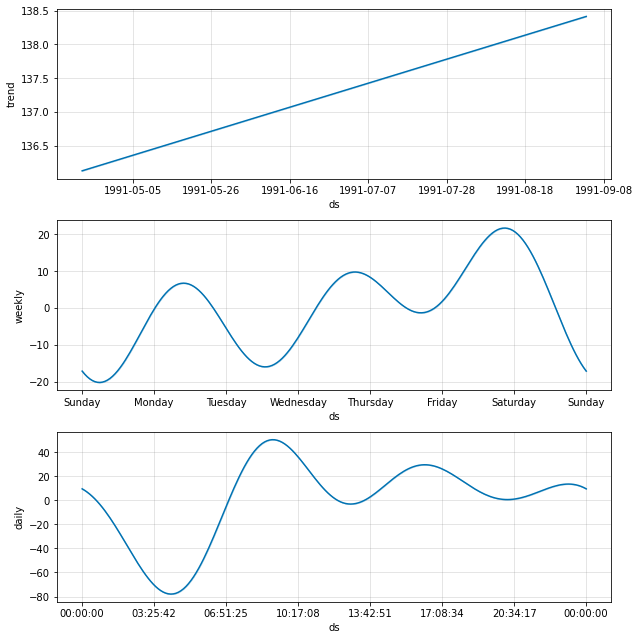

```python
fig2 = prophet.plot_components(forecast)
```

Prophet's predictions are reasonable and given the confidence intervals we see that mostly the model performs well. Probably, the most valuable information comes from the trends and seasonal graphs where we see that the patient's blood glucose shows spikes on Saturdays and in the mornings.

It is worth noting that this is not a medical prediction as diabetes is a far more complex phenomenon. Here the predictions are based soleley on past values collected under the assumption that the patient maintains the same habits.